# The ChIPpeakAnno user’s guide

# Detailed Use Cases and Scenarios

Here we describe some details in using different functions in `ChIPpeakAnno` for different tasks. As shown in the last section, the common workflow includes: loading called peaks from BED, GFF, or other formats; evaluating and visualizing the concordance among the biological replicates; combining peaks from replicates; preparing genomic annotation(s) as GRanges; associating/annotating peaks with the annotation(s); summarizing peak distributions over exon, intron, enhancer, proximal promoter, 5’UTR and 3’UTR regions; retrieving the sequences around the peaks; and enrichment analysis of GO and biological pathway. We also implemented the functions to plot the heatmap of given peak ranges, and perform permutation test to determine if there is a significant overlap between two sets of peaks.

## Determine the overlapping peaks and visualize the overlaps with Venn diagram

Prior to associating features of interest with the peaks, it is a common practice to evaluate the concordance among the peaks from biological replicates and combine the peaks from biological replicates. Also, it is biologically interesting to obtain overlapping peaks from different ChIP-seq experiments to imply the potential formation of transcription factor complexes. `ChIPpeakAnno` implemented functions to achieve those goals and quantitatively determine the significance of peak overlaps and generate a Venn diagram for visualization.

Here is the sample code to obtain the overlapping peaks with maximum gap of 1kb for two peak ranges.

```r
peaks1 <- GRanges(seqnames=c("1", "2", "3", "4", "5", "6",
                              "2", "6", "6", "6", "6", "5"),
                   ranges=IRanges(start=c(967654, 2010897, 2496704, 3075869,
                                          3123260, 3857501, 201089, 1543200,
                                          1557200, 1563000, 1569800, 167889600),
                                  end= c(967754, 2010997, 2496804, 3075969,
                                         3123360, 3857601, 201089, 1555199,
                                         1560599, 1565199, 1573799, 167893599),
                                  names=paste("Site", 1:12, sep="")),
                  strand="+")

peaks2 <- GRanges(seqnames=c("1", "2", "3", "4", "5", "6", "1", "2", "3",
                                     "4", "5", "6", "6", "6", "6", "6", "5"),
                          ranges=IRanges(start=c(967659, 2010898, 2496700,
                                                 3075866, 3123260, 3857500,
                                                 96765, 201089, 249670, 307586,
                                                 312326, 385750, 1549800,
                                                 1554400, 1565000, 1569400,
                                                 167888600),
                                         end=c(967869, 2011108, 2496920,
                                               3076166,3123470, 3857780,
                                               96985, 201299, 249890, 307796,
                                               312586, 385960, 1550599, 1560799,
                                               1565399, 1571199, 167888999),
                                         names=paste("t", 1:17, sep="")),
                          strand=c("+", "+", "+", "+", "+", "+", "-", "-", "-",
                                   "-", "-", "-", "+", "+", "+", "+", "+"))

ol <- findOverlapsOfPeaks(peaks1, peaks2, maxgap=1000)
peaklist <- ol$peaklist
```

The function `findOverlapsOfPeaks` returns an object of **overlappingPeaks**, which contains there elements: venn_cnt, peaklist (a list of  
overlapping peaks or unique peaks), and overlappingPeaks (a list of data frame consists of the annotation of all the overlapping peaks).

Within the overlappingPeaks element of the **overlappingPeaks** object ol (which is also a list), the element “peaks1///peaks2” is a data frame representing the overlapping peaks with maximum gap of 1kb between the two peak lists. Using the overlapFeature column in this data frame, a pie graph can be generated to describe the distribution of the features of the relative positions of peaks1 to peaks2 for the overlapping peaks.

```r
overlappingPeaks <- ol$overlappingPeaks
names(overlappingPeaks)
```

```
## [1] "peaks1///peaks2"
```

```r
dim(overlappingPeaks[["peaks1///peaks2"]])
```

```
## [1] 13 14
```

```r
overlappingPeaks[["peaks1///peaks2"]][1:2, ]
```

```
##          peaks1 seqnames   start     end width strand peaks2 seqnames   start
## Site1_t1  Site1        1  967654  967754   101      +     t1        1  967659
## Site2_t2  Site2        2 2010897 2010997   101      +     t2        2 2010898
##              end width strand overlapFeature shortestDistance
## Site1_t1  967869   211      +   overlapStart                5
## Site2_t2 2011108   211      +   overlapStart                1
```

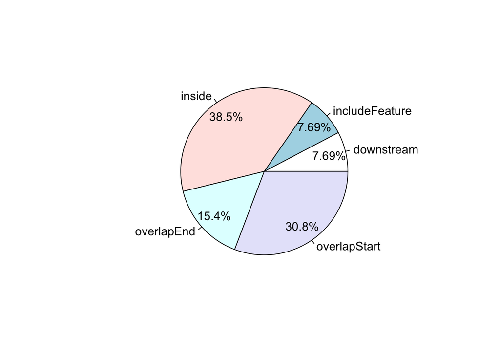

Pie chart of common peaks among features.

```r
pie1(table(overlappingPeaks[["peaks1///peaks2"]]$overlapFeature))
```

The following code returns the merged overlapping peaks from the peaklist object.

```r
peaklist[["peaks1///peaks2"]]
```

```
## GRanges object with 11 ranges and 1 metadata column:
##        seqnames              ranges strand |
##           <Rle>           <IRanges>  <Rle> |
##    [1]        1       967654-967869      + |
##    [2]        2       201089-201299      * |
##    [3]        2     2010897-2011108      + |
##    [4]        3     2496700-2496920      + |
##    [5]        4     3075866-3076166      + |
##    [6]        5     3123260-3123470      + |
##    [7]        5 167888600-167893599      + |
##    [8]        6     1543200-1560799      + |
##    [9]        6     1563000-1565399      + |
##   [10]        6     1569400-1573799      + |
##   [11]        6     3857500-3857780      + |
##                                        peakNames
##                                  <CharacterList>
##    [1]                  peaks1__Site1,peaks2__t1
##    [2]                  peaks1__Site7,peaks2__t8
##    [3]                  peaks1__Site2,peaks2__t2
##    [4]                  peaks2__t3,peaks1__Site3
##    [5]                  peaks2__t4,peaks1__Site4
##    [6]                  peaks1__Site5,peaks2__t5
##    [7]                peaks2__t17,peaks1__Site12
##    [8] peaks1__Site8,peaks2__t13,peaks2__t14,...
##    [9]                peaks1__Site10,peaks2__t15
##   [10]                peaks2__t16,peaks1__Site11
##   [11]                  peaks2__t6,peaks1__Site6
##   -------
##   seqinfo: 6 sequences from an unspecified genome; no seqlengths
```

The peaks in peaks1 but not overlap with the peaks in peaks2 can be obtained with:

```r
peaklist[["peaks1"]]
```

[output not shown]

The peaks in peaks2 but not overlap with the peaks in peaks1 can be obtained with:

```r
peaklist[["peaks2"]]
```

```
## GRanges object with 5 ranges and 1 metadata column:
##       seqnames        ranges strand |       peakNames
##          <Rle>     <IRanges>  <Rle> | <CharacterList>
##   [1]        1   96765-96985      - |      peaks2__t7
##   [2]        3 249670-249890      - |      peaks2__t9
##   [3]        4 307586-307796      - |     peaks2__t10
##   [4]        5 312326-312586      - |     peaks2__t11
##   [5]        6 385750-385960      - |     peaks2__t12
##   -------
##   seqinfo: 6 sequences from an unspecified genome; no seqlengths
```

Venn diagram can be generated by the function `makeVennDiagram` using the output of `findOverlapsOfPeaks` as an input.

The `makeVennDiagram` also outputs p-values indicating whether the overlapping is significant.

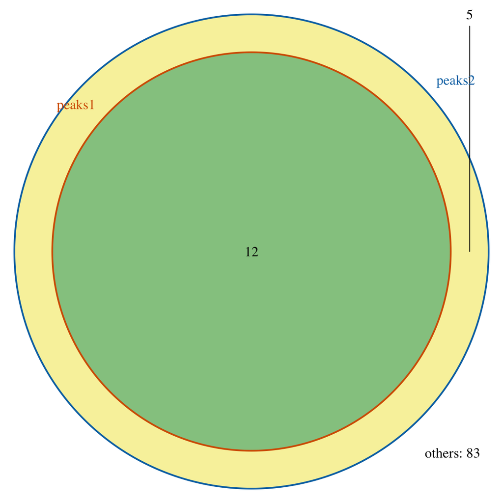

venn diagram of overlaps

```
## $p.value
##      peaks1 peaks2         pval
## [1,]      1      1 5.890971e-12
##
## $vennCounts
##      peaks1 peaks2 Counts count.peaks1 count.peaks2
## [1,]      0      0     83            0            0
## [2,]      0      1      5            0            5
## [3,]      1      0      0            0            0
## [4,]      1      1     12           12           12
## attr(,"class")
## [1] "VennCounts"
```

```r
makeVennDiagram(ol, totalTest=1e+2,
                fill=c("#009E73", "#F0E442"), # circle fill color
                col=c("#D55E00", "#0072B2"), #circle border color
                cat.col=c("#D55E00", "#0072B2"))
```

Alternatively, users have the option to use other tools to plot Venn diagram. The following code demonstrates how to use a third party R package **Vernerable** with the output from the function `findOverlapsOfPeaks`.

```r
#     install.packages("Vennerable", repos="http://R-Forge.R-project.org",
#                     type="source")
#     library(Vennerable)
#     venn_cnt2venn <- function(venn_cnt){
#         n <- which(colnames(venn_cnt)=="Counts") - 1
#         SetNames=colnames(venn_cnt)[1:n]
#         Weight=venn_cnt[,"Counts"]
#         names(Weight) <- apply(venn_cnt[,1:n], 1, base::paste, collapse="")
#         Venn(SetNames=SetNames, Weight=Weight)
#     }
#
#     v <- venn_cnt2venn(ol$venn_cnt)
#     plot(v)
```

The `findOverlapsOfPeaks` function accepts up to 5 peak lists for overlapping peaks. The following code is an example for 3 peak lists.

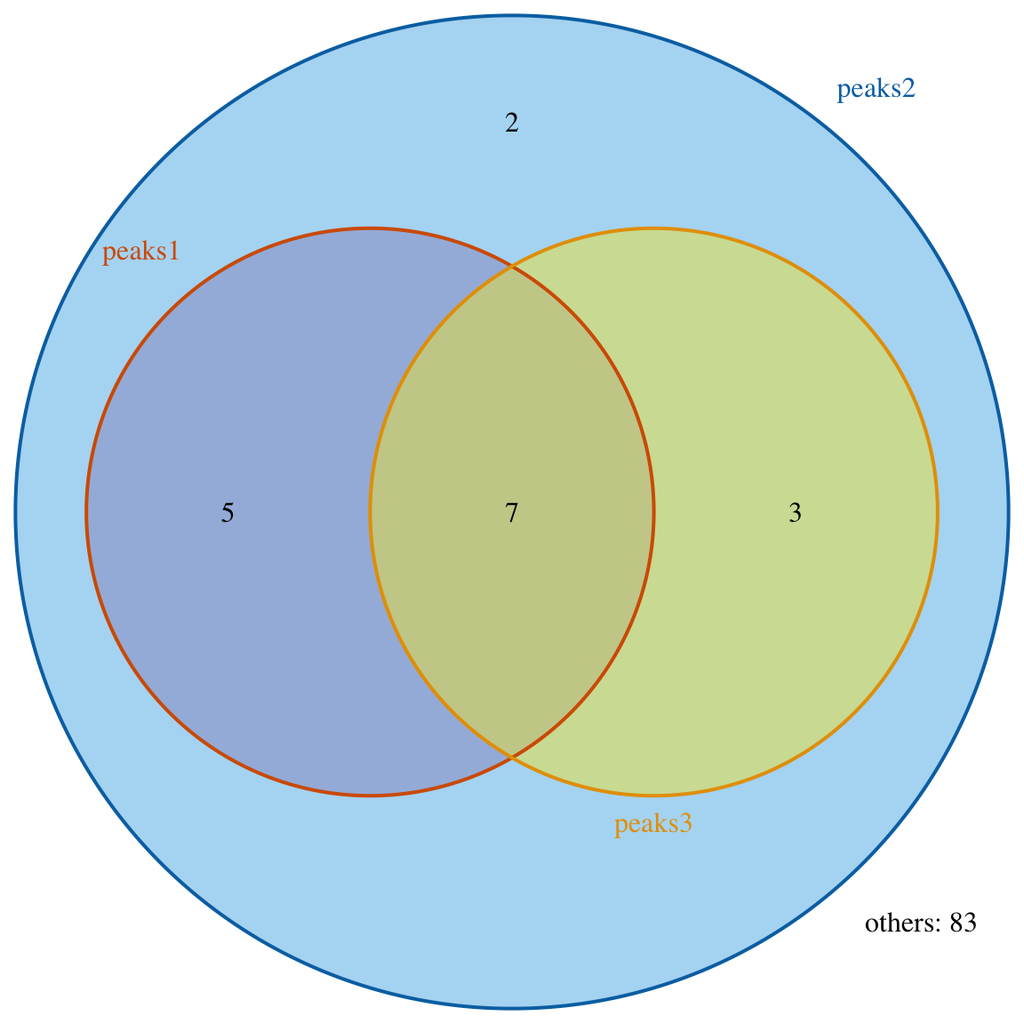

venn diagram of overlaps for three input peak lists

```
## $p.value
##      peaks1 peaks2 peaks3         pval
## [1,]      0      1      1 1.123492e-09
## [2,]      1      0      1 5.131347e-06
## [3,]      1      1      0 5.890971e-12
##
## $vennCounts
##      peaks1 peaks2 peaks3 Counts
## [1,]      0      0      0     83
## [2,]      0      0      1      0
## [3,]      0      1      0      2
## [4,]      0      1      1      3
## [5,]      1      0      0      0
## [6,]      1      0      1      0
## [7,]      1      1      0      5
## [8,]      1      1      1      7
## attr(,"class")
## [1] "VennCounts"
```

```r
peaks3 <- GRanges(seqnames=c("1", "2", "3", "4", "5",
                             "6", "1", "2", "3", "4"),
                   ranges=IRanges(start=c(967859, 2010868, 2496500, 3075966,
                                          3123460, 3851500, 96865, 201189,
                                          249600, 307386),
                                  end= c(967969, 2011908, 2496720, 3076166,
                                         3123470, 3857680, 96985, 201299,
                                         249890, 307796),
                                  names=paste("p", 1:10, sep="")),
                  strand=c("+", "+", "+", "+", "+",
                           "+", "-", "-", "-", "-"))

ol <- findOverlapsOfPeaks(peaks1, peaks2, peaks3, maxgap=1000,
                          connectedPeaks="min")
makeVennDiagram(ol, totalTest=1e+2,
                fill=c("#CC79A7", "#56B4E9", "#F0E442"), # circle fill color
                col=c("#D55E00", "#0072B2", "#E69F00"), #circle border color
                cat.col=c("#D55E00", "#0072B2", "#E69F00"))
```

The parameter *totalTest* in the function `makeVennDiagram` indicates the total number of potential peaks used in the hypergeometric test. It should be larger than the largest number of peaks in the replicates. The smaller it is set, the more stringent the test is. The time used to calculate p-value does not depend on the value of the totalTest. For practical guidance on how to choose *totalTest*, please refer to the [post](https://stat.ethz.ch/pipermail/bioconductor/2010-November/036540.html). Hypergeometric test requires users to input an estimate of the total potential binding sites (peaks) for a given TF. To circumvent this requirement, we implemented a permutation test called `permTest`. For more details about the `permTest`, go to section **4.11**.

## Generate annotation data

One main function of the **ChIPpeakAnno** package is to annotate peaks to known genomic features, such as TSS, 5’UTR, 3’UTR etc. Constructing and choosing the appropriate annotation data is crucial for this process.

To simplify this process, we precompiled a list of annotation data for the transcriptional starting sites (TSS) of various species (with different genome assembly versions), such as TSS.human.NCBI36, TSS.human.GRCh37, TSS.human.GRCh38, TSS.mouse.NCBIM37, TSS.mouse.GRCm38, TSS.rat.RGSC3.4, TSS.rat.Rnor_5.0, TSS.zebrafish.Zv8, and TSS.zebrafish.Zv9. The precompiled annotations can be loaded by R `data()` function, e.g., data(TSS.human.GRCh38).

To annotate the peaks with other genomic features, please use function `getAnnotation` with the argument *featureType*, e.g., “Exon” to obtain the nearest exon, “miRNA” to find the nearest miRNA, and “5utr” or “3utr” to locate the overlapping “5’UTR” or “3’UTR”. Another parameter for `getAnnotation` is the name of the appropriate biomaRt dataset, for example, drerio_gene_ensembl for zebrafish genome, mmusculus_gene_ensembl for mouse genome and rnorvegicus_gene_ensembl for rat genome. For a list of available biomaRt and dataset, please refer to the **biomaRt** package documentation<sup>2</sup>. For the detailed usage of `getAnnotation`, please type ?`getAnnotation` in R.

In addition, a custom annotation dataset as GRanges, can be used in `annotatePeakInBatch`. We implemented `toGRanges` function for converting custom annotation dataset in other formats, such as UCSC BED/GFF format, or any user defined dataset such as RangedDate, to GRanges. For example, if you have a list of transcription factor binding sites from literatures and are interested in locating the nearest TSS and the distance to it for the peak lists.

An GRanges object can be also constructed from EnsDb or TxDb object by calling the `toGRanges` method. Use ?`toGRanges` for more information.

Here is the code snippet to build annotation data containing only the known genes, i.e., excluding other transcript products such as pseudo genes using *TranscriptDb* TxDb.Hsapiens.UCSC.hg19.knownGene with `toGRanges` is:

```r
library(TxDb.Hsapiens.UCSC.hg19.knownGene)
annoData <- toGRanges(TxDb.Hsapiens.UCSC.hg19.knownGene, feature="gene")
annoData
```

```
## GRanges object with 23056 ranges and 0 metadata columns:
##         seqnames              ranges strand
##            <Rle>           <IRanges>  <Rle>
##       1    chr19   58858172-58874214      -
##      10     chr8   18248755-18258723      +
##     100    chr20   43248163-43280376      -
##    1000    chr18   25530930-25757445      -
##   10000     chr1 243651535-244006886      -
##     ...      ...                 ...    ...
##    9991     chr9 114979995-115095944      -
##    9992    chr21   35736323-35743440      +
##    9993    chr22   19023795-19109967      -
##    9994     chr6   90539619-90584155      +
##    9997    chr22   50961997-50964905      -
##   -------
##   seqinfo: 93 sequences (1 circular) from hg19 genome
```

## Find the nearest feature and the distance to the feature for the peaklists

With the annotation data, you can annotate the peaks identified from ChIP-seq or ChIP-chip experiments to retrieve the nearest gene and distance to the corresponding TSS of the gene.

For example, using the GRanges object generated in the previous section as AnnotationData, the first 6 peaks in the myPeakList are annotated with the following code:

```r
data(myPeakList)
annotatedPeak <- annotatePeakInBatch(myPeakList[1:6],
                                     AnnotationData = annoData)
annotatedPeak[1:3]
```

```
## GRanges object with 3 ranges and 9 metadata columns:
##                          seqnames        ranges strand |         peak
##                             <Rle>     <IRanges>  <Rle> |  <character>
##   X1_93_556427.100288069     chr1 556660-556760      * | X1_93_556427
##   X1_41_559455.100288069     chr1 559774-559874      * | X1_41_559455
##   X1_12_703729.100288069     chr1 703885-703985      * | X1_12_703729
##                              feature start_position end_position feature_strand
##                          <character>      <integer>    <integer>    <character>
##   X1_93_556427.100288069   100288069         700245       714068              -
##   X1_41_559455.100288069   100288069         700245       714068              -
##   X1_12_703729.100288069   100288069         700245       714068              -
##                          insideFeature distancetoFeature shortestDistance
##                            <character>         <numeric>        <integer>
##   X1_93_556427.100288069    downstream            157408           143485
##   X1_41_559455.100288069    downstream            154294           140371
##   X1_12_703729.100288069        inside             10183             3640
##                          fromOverlappingOrNearest
##                                       <character>
##   X1_93_556427.100288069          NearestLocation
##   X1_41_559455.100288069          NearestLocation
##   X1_12_703729.100288069          NearestLocation
##   -------
##   seqinfo: 24 sequences from an unspecified genome; no seqlengths
```

As discussed in the previous section, all the genomic locations of the human genes have been precompiled, such as TSS.human.NCBI36 dataset, using function `getAnnotation`. You can pass it to the argument *annotaionData* of the `annotatePeakInBatch` function.

```r
data(TSS.human.NCBI36)
annotatedPeak <- annotatePeakInBatch(myPeakList[1:6],
                 AnnotationData=TSS.human.NCBI36)
annotatedPeak[1:3]
```

```
## GRanges object with 3 ranges and 9 metadata columns:
##                                seqnames        ranges strand |         peak
##                                   <Rle>     <IRanges>  <Rle> |  <character>
##   X1_93_556427.ENSG00000212875     chr1 556660-556760      * | X1_93_556427
##   X1_41_559455.ENSG00000212678     chr1 559774-559874      * | X1_41_559455
##   X1_12_703729.ENSG00000197049     chr1 703885-703985      * | X1_12_703729
##                                        feature start_position end_position
##                                    <character>      <integer>    <integer>
##   X1_93_556427.ENSG00000212875 ENSG00000212875         556318       557859
##   X1_41_559455.ENSG00000212678 ENSG00000212678         559620       560165
##   X1_12_703729.ENSG00000197049 ENSG00000197049         711184       712376
##                                feature_strand insideFeature distancetoFeature
##                                   <character>   <character>         <numeric>
##   X1_93_556427.ENSG00000212875              +        inside               342
##   X1_41_559455.ENSG00000212678              +        inside               154
##   X1_12_703729.ENSG00000197049              +      upstream             -7299
##                                shortestDistance fromOverlappingOrNearest
##                                       <integer>              <character>
##   X1_93_556427.ENSG00000212875              342          NearestLocation
##   X1_41_559455.ENSG00000212678              154          NearestLocation
##   X1_12_703729.ENSG00000197049             7199          NearestLocation
##   -------
##   seqinfo: 24 sequences from an unspecified genome; no seqlengths
```

You can also pass the user defined features as annotationData. A pie chart can be plotted to show the peak distribution among the features after annotation.

```r
myPeak1 <- GRanges(seqnames=c("1", "2", "3", "4", "5", "6",
                              "2", "6", "6", "6", "6", "5"),
                   ranges=IRanges(start=c(967654, 2010897, 2496704, 3075869,
                                          3123260, 3857501, 201089, 1543200,
                                          1557200, 1563000, 1569800, 167889600),
                                  end= c(967754, 2010997, 2496804, 3075969,
                                         3123360, 3857601, 201089, 1555199,
                                         1560599, 1565199, 1573799, 167893599),
                                  names=paste("Site", 1:12, sep="")))

TFbindingSites <- GRanges(seqnames=c("1", "2", "3", "4", "5", "6", "1", "2",
                                     "3", "4", "5", "6", "6", "6", "6", "6",
                                     "5"),
                          ranges=IRanges(start=c(967659, 2010898, 2496700,
                                                 3075866, 3123260, 3857500,
                                                 96765, 201089, 249670, 307586,
                                                 312326, 385750, 1549800,
                                                 1554400, 1565000, 1569400,
                                                 167888600),
                                         end=c(967869, 2011108, 2496920,
                                               3076166,3123470, 3857780,
                                               96985, 201299, 249890, 307796,
                                               312586, 385960, 1550599, 1560799,
                                               1565399, 1571199, 167888999),
                                         names=paste("t", 1:17, sep="")),
                          strand=c("+", "+", "+", "+", "+", "+", "-", "-", "-",
                                   "-", "-", "-", "+", "+", "+", "+", "+"))

annotatedPeak2 <- annotatePeakInBatch(myPeak1, AnnotationData=TFbindingSites)
annotatedPeak2[1:3]
```

```
## GRanges object with 3 ranges and 9 metadata columns:
##            seqnames          ranges strand |        peak     feature
##               <Rle>       <IRanges>  <Rle> | <character> <character>
##   Site1.t1        1   967654-967754      * |       Site1          t1
##   Site2.t2        2 2010897-2010997      * |       Site2          t2
##   Site3.t3        3 2496704-2496804      * |       Site3          t3
##            start_position end_position feature_strand insideFeature
##                 <integer>    <integer>    <character>   <character>
##   Site1.t1         967659       967869              +  overlapStart
##   Site2.t2        2010898      2011108              +  overlapStart
##   Site3.t3        2496700      2496920              +        inside
##            distancetoFeature shortestDistance fromOverlappingOrNearest
##                    <numeric>        <integer>              <character>
##   Site1.t1                -5                5          NearestLocation
##   Site2.t2                -1                1          NearestLocation
##   Site3.t3                 4                4          NearestLocation
##   -------
##   seqinfo: 6 sequences from an unspecified genome; no seqlengths
```

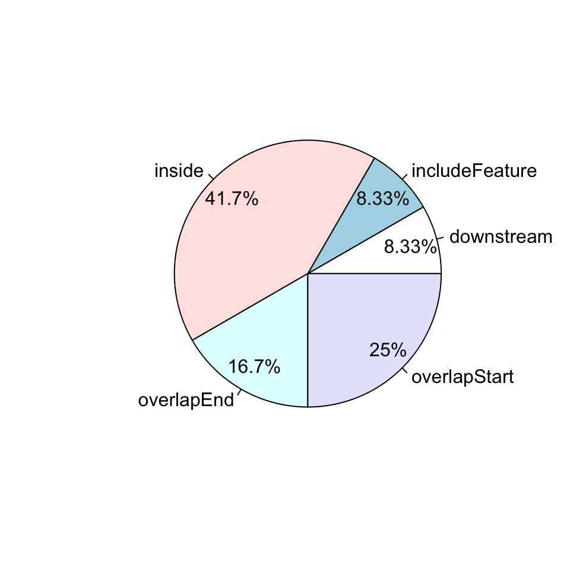

Pie chart of peak distribution among features

```r
pie1(table(as.data.frame(annotatedPeak2)$insideFeature))
```

Another example of using user defined *AnnotationData* is to annotate peaks by promoters, defined as upstream 5K to downstream 500bp from TSS. The sample code here demonstrates using the `GenomicFeatures::promoters` function to build a custom annotation dataset and annotate the peaks with this user defined promoter annotations.

```r
library(ChIPpeakAnno)
data(myPeakList)
data(TSS.human.NCBI36)
annotationData <- promoters(TSS.human.NCBI36, upstream=5000, downstream=500)
annotatedPeak <- annotatePeakInBatch(myPeakList[1:6,],
                                     AnnotationData=annotationData,
                                     output="overlapping")
annotatedPeak[1:3]
```

```
## GRanges object with 3 ranges and 9 metadata columns:
##                                seqnames        ranges strand |         peak
##                                   <Rle>     <IRanges>  <Rle> |  <character>
##   X1_93_556427.ENSG00000209341     chr1 556660-556760      * | X1_93_556427
##   X1_93_556427.ENSG00000209344     chr1 556660-556760      * | X1_93_556427
##   X1_93_556427.ENSG00000209346     chr1 556660-556760      * | X1_93_556427
##                                        feature start_position end_position
##                                    <character>      <integer>    <integer>
##   X1_93_556427.ENSG00000209341 ENSG00000209341         554314       559813
##   X1_93_556427.ENSG00000209344 ENSG00000209344         555569       561068
##   X1_93_556427.ENSG00000209346 ENSG00000209346         555643       561142
##                                feature_strand insideFeature distancetoFeature
##                                   <character>   <character>         <numeric>
##   X1_93_556427.ENSG00000209341              -        inside              3153
##   X1_93_556427.ENSG00000209344              -        inside              4408
##   X1_93_556427.ENSG00000209346              -        inside              4482
##                                shortestDistance fromOverlappingOrNearest
##                                       <integer>              <character>
##   X1_93_556427.ENSG00000209341             2346              Overlapping
##   X1_93_556427.ENSG00000209344             1091              Overlapping
##   X1_93_556427.ENSG00000209346             1017              Overlapping
##   -------
##   seqinfo: 24 sequences from an unspecified genome; no seqlengths
```

In the function `annotatyePeakInBatch`, various parameters can be adjusted to specify the way to calculate the distance and how the features are selected. For example, *PeakLocForDistance* is to specify the location of the peak for distance calculation: “middle” (recommended) means using the middle of the peak, and “start” (default, for backward compatibility) means using the start of the peak to calculate the distance to the features. Similarly, *FeatureLocForDistance* is to specify the location of the feature for distance calculation: “middle” means using the middle of the feature, “start” means using the start of the feature to calculate the distance from the peak to the feature; “TSS” (default) means using the start of the feature when the feature is on plus strand and using the end of feature when the feature is on minus strand; “geneEnd” means using end of the feature when feature is on plus strand and using start of feature when feature is on minus strand.

The argument “output” specifies the characteristics of the output of the annotated features. The default is “nearestLocation”, which means to output the nearest features calculated as PeakLocForDistance-FeatureLocForDistance; “overlapping” will output the overlapping features within the maximum gap specified as maxgap between the peak range and feature range; “shortestDistance” will output the nearest features; “both” will output all the nearest features, in addition, will output any features that overlap the peak that are not the nearest features. other options see ?annotatePeakInBatch.

## Find the overlapping and flanking features

In addition to annotating peaks to nearest genes, **ChIPpeakAnno** can also reports all overlapping and flanking genes by setting output=“both” and maxgap in `annotatePeakInBatch`. For example, it outputs all overlapping and flanking genes within 5kb plus nearest genes if set maxgap = 5000 and output =“both”.

```r
annotatedPeak <- annotatePeakInBatch(myPeakList[1:6],
                                     AnnotationData = annoData,
                                     output="both", maxgap=5000)
head(annotatedPeak)
```

```
## GRanges object with 6 ranges and 9 metadata columns:
##                          seqnames          ranges strand |          peak
##                             <Rle>       <IRanges>  <Rle> |   <character>
##   X1_93_556427.100288069     chr1   556660-556760      * |  X1_93_556427
##   X1_41_559455.100288069     chr1   559774-559874      * |  X1_41_559455
##   X1_12_703729.100288069     chr1   703885-703985      * |  X1_12_703729
##       X1_20_925025.84808     chr1   926058-926158      * |  X1_20_925025
##      X1_11_1041174.54991     chr1 1041646-1041746      * | X1_11_1041174
##       X1_14_1269014.1855     chr1 1270239-1270339      * | X1_14_1269014
##                              feature start_position end_position feature_strand
##                          <character>      <integer>    <integer>    <character>
##   X1_93_556427.100288069   100288069         700245       714068              -
##   X1_41_559455.100288069   100288069         700245       714068              -
##   X1_12_703729.100288069   100288069         700245       714068              -
##       X1_20_925025.84808       84808         910579       917473              -
##      X1_11_1041174.54991       54991        1017198      1051736              -
##       X1_14_1269014.1855        1855        1270658      1284492              -
##                          insideFeature distancetoFeature shortestDistance
##                            <character>         <numeric>        <integer>
##   X1_93_556427.100288069    downstream            157408           143485
##   X1_41_559455.100288069    downstream            154294           140371
##   X1_12_703729.100288069        inside             10183             3640
##       X1_20_925025.84808      upstream             -8585             8585
##      X1_11_1041174.54991        inside             10090             9990
##       X1_14_1269014.1855    downstream             14253              319
##                          fromOverlappingOrNearest
##                                       <character>
##   X1_93_556427.100288069          NearestLocation
##   X1_41_559455.100288069          NearestLocation
##   X1_12_703729.100288069          NearestLocation
##       X1_20_925025.84808          NearestLocation
##      X1_11_1041174.54991          NearestLocation
##       X1_14_1269014.1855              Overlapping
##   -------
##   seqinfo: 24 sequences from an unspecified genome; no seqlengths
```

## Add other feature IDs to the annotated peaks

Additional annotations features such as entrez ID, gene symbol and gene name can be added with the function `addGeneIDs`. The annotated peaks can be saved as an Excel file or plotted for visualizing the peak distribution relative to the genomic features of interest. Here is an example to add gene symbol to the annotated peaks. Please type ?`addGeneIDs` in a R session for more information.

```r
data(annotatedPeak)
library(org.Hs.eg.db)
addGeneIDs(annotatedPeak[1:6], orgAnn="org.Hs.eg.db", IDs2Add=c("symbol"))
```

```
## GRanges object with 6 ranges and 9 metadata columns:
##                                   seqnames              ranges strand |
##                                      <Rle>           <IRanges>  <Rle> |
##   X1_11_100272487.ENSG00000202254        1 100272801-100272900      + |
##   X1_11_108905539.ENSG00000186086        1 108906026-108906125      + |
##   X1_11_110106925.ENSG00000065135        1 110107267-110107366      + |
##   X1_11_110679983.ENSG00000197106        1 110680469-110680568      + |
##   X1_11_110681677.ENSG00000197106        1 110682125-110682224      + |
##   X1_11_110756560.ENSG00000116396        1 110756823-110756922      + |
##                                             peak         feature start_position
##                                      <character>     <character>      <numeric>
##   X1_11_100272487.ENSG00000202254 1_11_100272487 ENSG00000202254      100257218
##   X1_11_108905539.ENSG00000186086 1_11_108905539 ENSG00000186086      108918435
##   X1_11_110106925.ENSG00000065135 1_11_110106925 ENSG00000065135      110091233
##   X1_11_110679983.ENSG00000197106 1_11_110679983 ENSG00000197106      110693108
##   X1_11_110681677.ENSG00000197106 1_11_110681677 ENSG00000197106      110693108
##   X1_11_110756560.ENSG00000116396 1_11_110756560 ENSG00000116396      110753965
##                                   end_position insideFeature distancetoFeature
##                                      <numeric>   <character>         <numeric>
##   X1_11_100272487.ENSG00000202254    100257309    downstream             15582
##   X1_11_108905539.ENSG00000186086    109013624      upstream            -12410
##   X1_11_110106925.ENSG00000065135    110136975        inside             16033
##   X1_11_110679983.ENSG00000197106    110744824      upstream            -12640
##   X1_11_110681677.ENSG00000197106    110744824      upstream            -10984
##   X1_11_110756560.ENSG00000116396    110776666        inside              2857
##                                   shortestDistance fromOverlappingOrNearest
##                                          <numeric>              <character>
##   X1_11_100272487.ENSG00000202254            15491             NearestStart
##   X1_11_108905539.ENSG00000186086            12310             NearestStart
##   X1_11_110106925.ENSG00000065135            16033             NearestStart
##   X1_11_110679983.ENSG00000197106            12540             NearestStart
##   X1_11_110681677.ENSG00000197106            10884             NearestStart
##   X1_11_110756560.ENSG00000116396             2857             NearestStart
##                                        symbol
##                                   <character>
##   X1_11_100272487.ENSG00000202254        <NA>
##   X1_11_108905539.ENSG00000186086       NBPF6
##   X1_11_110106925.ENSG00000065135       GNAI3
##   X1_11_110679983.ENSG00000197106     SLC6A17
##   X1_11_110681677.ENSG00000197106     SLC6A17
##   X1_11_110756560.ENSG00000116396       KCNC4
##   -------
##   seqinfo: 24 sequences from an unspecified genome; no seqlengths
```

```r
addGeneIDs(annotatedPeak$feature[1:6], orgAnn="org.Hs.eg.db",
           IDs2Add=c("symbol"))
```

```
##   ensembl_gene_id  symbol
## 1 ENSG00000065135   GNAI3
## 2 ENSG00000116396   KCNC4
## 3 ENSG00000197106 SLC6A17
## 4 ENSG00000186086   NBPF6
## 5 ENSG00000202254    <NA>
```

## Obtain the sequences surrounding the peaks

Here is an example to get the sequences of the peaks plus 20 bp upstream and downstream for PCR validation or motif discovery.

```r
peaks <- GRanges(seqnames=c("NC_008253", "NC_010468"),
                 ranges=IRanges(start=c(100, 500),
                                end=c(300, 600),
                                names=c("peak1", "peak2")))
library(BSgenome.Ecoli.NCBI.20080805)
peaksWithSequences <- getAllPeakSequence(peaks, upstream=20,
                                         downstream=20, genome=Ecoli)
```

The obtained sequences can be converted to fasta format for motif discovery by calling the function `write2FASTA`.

```r
write2FASTA(peaksWithSequences,"test.fa")
```

## Create heatmap for given feature/peak ranges

You can easily visualize and compare the binding patterns of raw signals of multiple ChIP-Seq experiments using function `featureAlignedHeatmap` and `featureAlignedDistribution`.

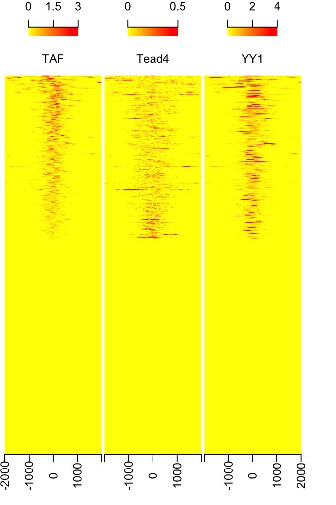

Heatmap of aligned features

```r
path <- system.file("extdata", package="ChIPpeakAnno")
files <- dir(path, "broadPeak")
data <- sapply(file.path(path, files), toGRanges, format="broadPeak")
names(data) <- gsub(".broadPeak", "", files)
ol <- findOverlapsOfPeaks(data)
#makeVennDiagram(ol)
features <- ol$peaklist[[length(ol$peaklist)]]
wid <- width(features)
feature.recentered <- feature.center <- features
start(feature.center) <- start(features) + floor(wid/2)
width(feature.center) <- 1
start(feature.recentered) <- start(feature.center) - 2000
end(feature.recentered) <- end(feature.center) + 2000
## here we also suggest importData function in bioconductor trackViewer package
## to import the coverage.
## compare rtracklayer, it will save you time when handle huge dataset.
library(rtracklayer)
files <- dir(path, "bigWig")
if(.Platform$OS.type != "windows"){
    cvglists <- sapply(file.path(path, files), import,
                       format="BigWig",
                       which=feature.recentered,
                       as="RleList")
}else{## rtracklayer can not import bigWig files on Windows
    load(file.path(path, "cvglist.rds"))
}
names(cvglists) <- gsub(".bigWig", "", files)
sig <- featureAlignedSignal(cvglists, feature.center,
                            upstream=2000, downstream=2000)
heatmap <- featureAlignedHeatmap(sig, feature.center,
                                 upstream=2000, downstream=2000,
                                 upper.extreme=c(3,.5,4))
```

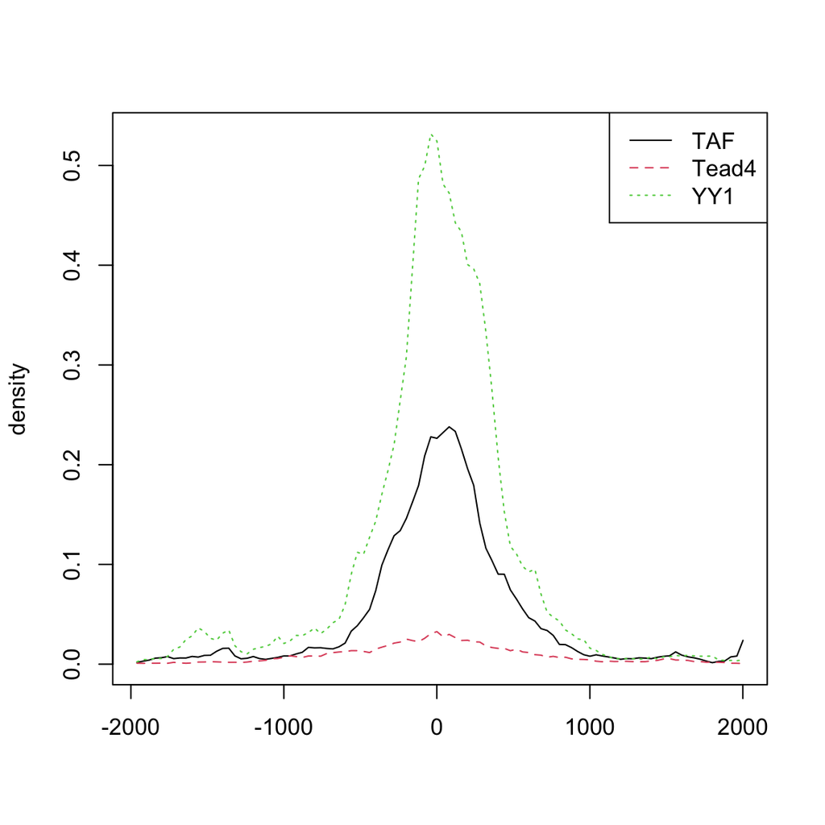

Distribution of aligned features

```r
featureAlignedDistribution(sig, feature.center,
                           upstream=2000, downstream=2000,
                           type="l")
```